# Gsynth implementation

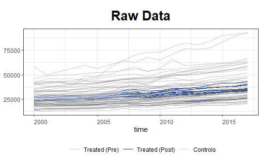

```r
plot(out_n2, type = "raw", theme.bw = TRUE)
```

```
Loadings for the first factor are shown...
```

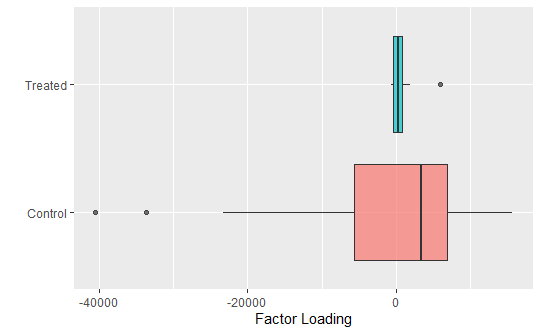

```r
plot(out_n2, type = "loadings")
```

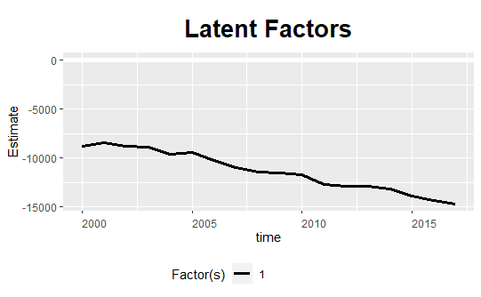

```r
plot(out_n2, type = "factors")
```

```r
out_n2$lambda.tr
```

```
                r1
DE11C   -0.1760897
DE135 -695.7923278
DE143 1927.1593205
DE724  736.4882703
DEA15 1099.3704827
DEA18    1.3118525
DEA1C -540.6449506
DEA2B 5939.0173234
DEA5A -243.3009421
DED51  542.7813000
DEE03  502.0008476
DEG01 -599.1006303
```

Now that I have restricted the sameple to those cities which I can create a Synthetic control y do the results:

### 4. Outcome

```r
n3_dta <- main_dta %>%

  # Treated that have good synths or controls
  filter(geo %in% out_n2$id.tr | !treated_uz ) %>%

  filter(treated_uz | contr_restr_60km) %>%
  # filter((treated_uz | contr_restr_point) &
  #          contr_restr_30km == FALSE ) %>% # Effect of non-vehicle change effects
  filter(!(geo %in% not_optimal_treated)) %>%

  filter(country == "DE")
  # filter(country %in% c("DE",
  #                       "NL", "BE", "AT",
  #                       "SE", "NO", "FI"
  #                       ))
  # filter(!(country %in% c("EL", "ES", "PT"))) %>% #,"PL", "TR")))

# Minimum pop density in sample and in treated
n3_dta$pop_km2 %>% summary()
```

```
   Min. 1st Qu.  Median    Mean 3rd Qu.    Max.    NA's
   36.3   109.5   194.4   523.8   851.1  2775.2     270
```

```r
n3_dta[n3_dta$treated_uz == TRUE, ]$pop_km2 %>% summary()
```

```
   Min. 1st Qu.  Median    Mean 3rd Qu.    Max.    NA's
  191.2   212.0   962.2   879.5  1496.2  1967.7      20
```

```r
n3_dta <- n3_dta %>%
  filter(pop_km2 > 100) %>% #avoid rural areas
  group_by(geo) %>%
  filter( # Restrict outcome range to reduce interpolation biases
    mean(gdp_eur_hab, na.rm = TRUE) < 75000,
    mean(gdp_eur_hab, na.rm = TRUE) > 15000
  ) %>%
  ungroup()


# Delete data of Magdeburg after the 2013 floods
n3_dta <- n3_dta %>%
  filter(!(geo == "DEE03" & time >= 2013))


# Perform analysis

out_n2 <- gsynth(gdp_eur_hab ~ is_announced,
               data = n3_dta,
               index = c("geo","time"),
               na.rm = TRUE, # remove NA
               force = "time", # unit or time fixed effects or both?
               CV = TRUE,
               r = c(0,5), # an integer specifying the number of factors. If CV = TRUE, the cross validation procedure will select the optimal number of factors from r to 5.
               se = TRUE,
               EM = TRUE, # Gobillon and Magnac (takes a lot of time)
               inference = "parametric",
               # estimator = "mc",
               nboots = 1000,  #500
               parallel = TRUE, cores = 5, # if do parallel and how many cores
               min.T0 = 7) # Has to be larger than r.max+1
```

```
Parallel computing ...
Cross-validating ...

 r = 0; sigma2 = 132310338.72135; IC = 18.70066; MSPE = 5210827.79788
 r = 1; sigma2 = 3541505.40106; IC = 15.61192; MSPE = 618791.80367
 r = 2; sigma2 = 1321363.57684; IC = 15.14657; MSPE = 493401.56214*
 r = 3; sigma2 = 977074.16384; IC = 15.35394; MSPE = 575258.94830
 r = 4; sigma2 = 706485.86849; IC = 15.52759; MSPE = 621133.93504
 r = 5; sigma2 = 574879.08014; IC = 15.80804; MSPE = 725345.65335

 r* = 2


Bootstrapping ...
```

```r
out_n2 %>% print()
```

```
Call:
gsynth.formula(formula = gdp_eur_hab ~ is_announced, data = n3_dta,
    na.rm = TRUE, index = c("geo", "time"), force = "time",
    r = c(0, 5), CV = TRUE, EM = TRUE, se = TRUE, nboots = 1000,
    inference = "parametric", parallel = TRUE, cores = 5,
    min.T0 = 7)

Average Treatment Effect on the Treated:
 ATT.avg  S.E. CI.lower CI.upper p.value
  -846.1 456.5    -1916   -128.6    0.03

   ~ by Period (including Pre-treatment Periods):
         ATT   S.E. CI.lower CI.upper p.value n.Treated
-8    31.534  288.7   -485.5    625.1   0.936         0
-7   124.359  307.4   -446.4    773.3   0.586         0
-6   -69.657  296.9   -619.5    532.7   0.894         0
-5     9.037  314.6   -581.9    648.4   0.936         0
-4   157.205  366.1   -562.5    850.8   0.710         0
-3   -53.545  351.2   -761.5    620.6   0.804         0
-2  -106.256  340.4   -792.5    510.5   0.714         0
-1   -34.144  266.8   -641.2    432.1   0.734         0
0   -281.368  318.4   -952.3    281.0   0.254         0
1   -351.127  434.8  -1331.9    372.8   0.266        10
2   -530.515  446.0  -1488.4    287.6   0.156        10
3   -800.490  555.7  -1969.9    155.8   0.092         7
4  -1242.388  587.0  -2545.3   -266.2   0.016         7
5  -1011.952  685.0  -2553.2    150.9   0.070         6
6  -1066.213  741.3  -2740.3    170.4   0.082         6
7  -1535.417 1236.5  -4481.6    560.9   0.120         2
8  -1546.126 1839.3  -5964.9    921.5   0.152         1
9  -2100.502 1989.0  -6912.7    704.0   0.110         1
```

```r
out_n2$Nco
```

```
[1] 67
```

```r
out_n2$Ntr
```

```
[1] 10
```

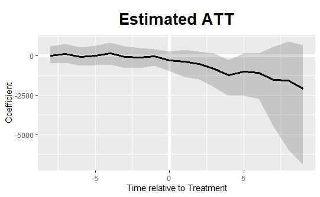

```r
# pdf(file="images/prelim_results/realATT.pdf",
#     width = 3.5, height = 3.1)
plot(out_n2) # ylim = c(-3500, 3500))
```

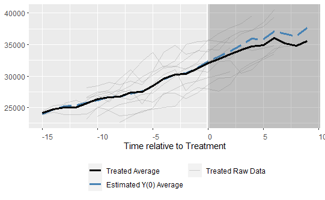

```r
# dev.off()

# plot all data:
plot(out_n2, type = "counterfactual",
     raw = "all", main="") # Why the final dip
```

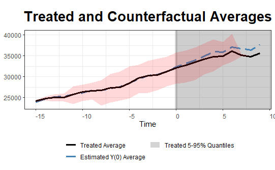

```r
# We can also add two 5 to 95% quantile bands of the treated and control outcomes as references to make sure the estimated counterfactuals are not results of severe extrapolations.

plot(out_n2, type = "counterfactual",
     raw = "band", xlab = "Time",
     # ylim = c(-5,35),
     theme.bw = TRUE)
```

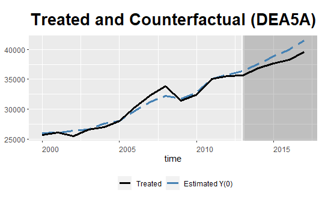

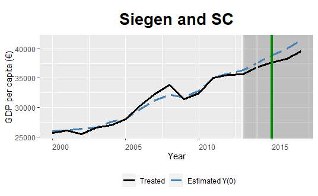

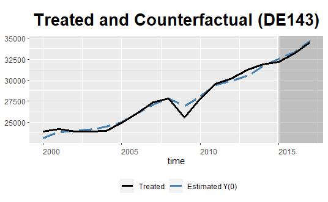

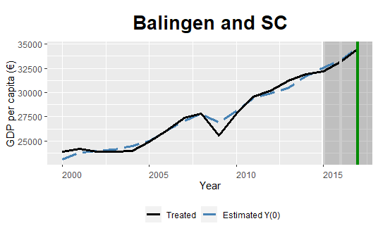

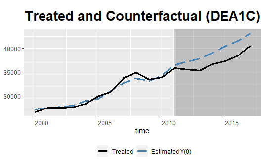

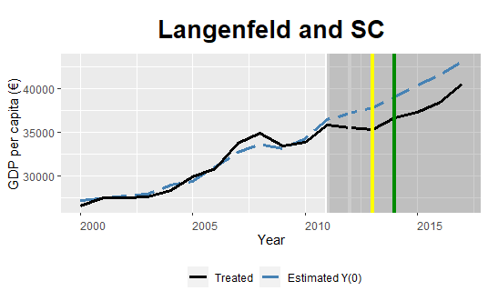

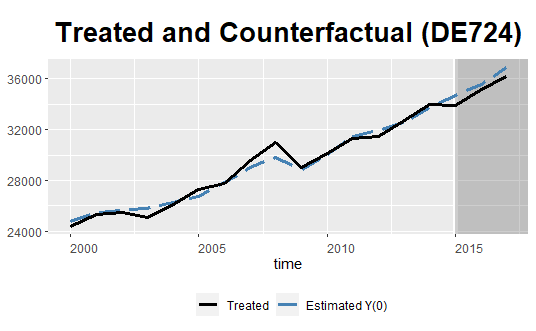

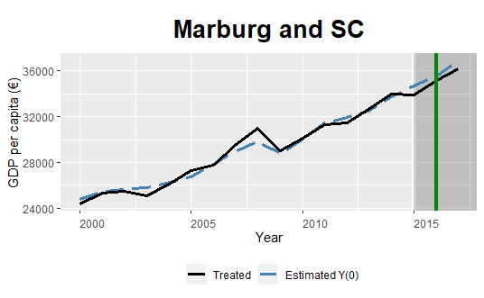

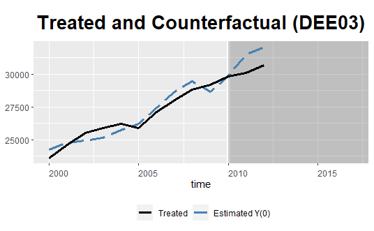

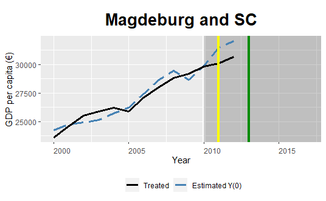

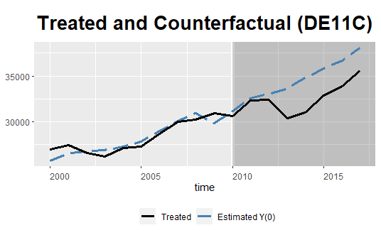

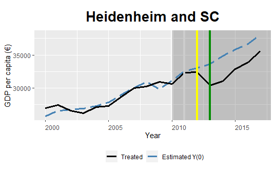

[8 more figures not shown]

```r
for (i in n3_dta[n3_dta$treated_uz == TRUE, ]$geo %>% unique()){
  if (i %in% out_n2$id.tr){
    temp <- plot(out_n2, type = "counterfactual", id = i)
    # pdf(file=paste0("images/prelim_results/ind_real",
    #               "_",  i, ".pdf"),
    # width = 3.5, height = 3.1)
    print(temp +
            geom_vline(xintercept = n3_dta[n3_dta$geo == i,
                                           ]$year_announced[1],
                       color = "grey80", size = 1.5) +
            geom_vline(xintercept = n3_dta[n3_dta$geo == i,
                                           ]$year_stage1[1],
                       color = "red1", size = 1.5) +
            geom_vline(xintercept = n3_dta[n3_dta$geo == i,
                                           ]$year_stage2[1],
                       color = "yellow1", size = 1.5) +
            geom_vline(xintercept = n3_dta[n3_dta$geo == i,
                                           ]$year_stage3[1],
                       color = "green4", size = 1.5) +
      labs(
        title = paste0(n3_dta[n3_dta$geo == i,]$LEZ[1],
                       " and SC"),
        y = "GDP per capita (€)",
        x  = "Year"
      )
    )
    # dev.off()
  }
}
```

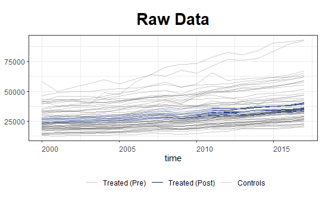

```r
plot(out_n2, type = "raw", theme.bw = TRUE)
```

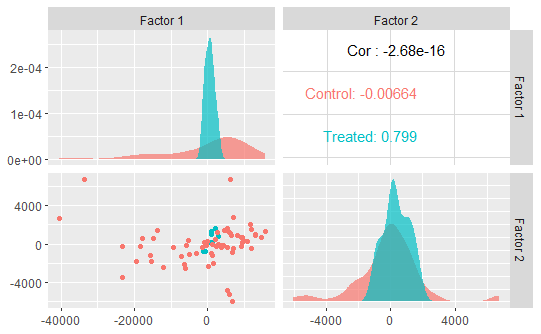

```r
# pdf(file="images/prelim_results/f_loadings.pdf",
#     width = 5, height = 4)
plot(out_n2, type = "loadings", main = "")
```

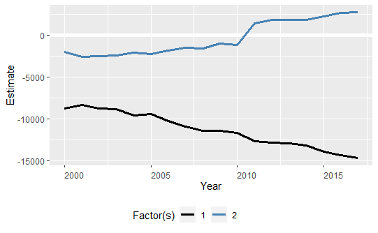

```r
# dev.off()


# pdf(file="images/prelim_results/factors_time.pdf",
#     width = 4, height = 3)
fact_ggplot <- plot(out_n2, type = "factors",
                    main = "",
                    xlab = "Year")
```

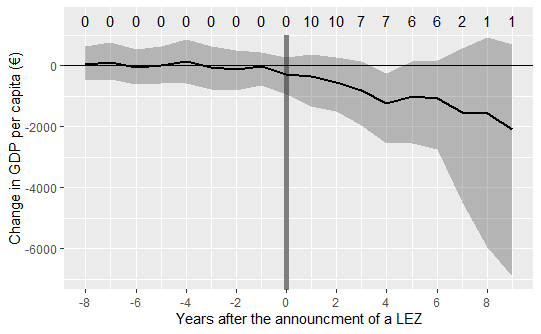

```r
# fact_ggplot +
#   labs(title = "",
#        x = "Year")
# dev.off()

# pdf(file="images/prelim_results/ATT_gdp_cap.pdf",
#     width = 5.5, height = 3)
out_n2$est.att %>%
  as_tibble(rownames = "rel_time") %>%
  mutate(rel_time = as.integer(rel_time)) %>%
  ggplot(aes(x= rel_time, y = ATT, group = 1)) +
  geom_segment(x = 0, xend = 0, y = -8000, yend = 1000,
               size = 2, color = "grey50") +
  geom_ribbon(aes(ymin = CI.lower, ymax = CI.upper),
              alpha = 0.3) +
  geom_line(size = 1) +
  geom_text(aes(x= rel_time, y = 1500, label = n.Treated)) +
  # geom_vline(xintercept = 0) +

  geom_hline(yintercept = 0) +
  labs(
    # title = "ATT and number of treated regions",
    x = "Years after the announcment of a LEZ",
    y = "Change in GDP per capita (€)"
  ) +
  scale_x_continuous(breaks=seq(-8,9,2)) +
  scale_y_continuous(breaks = seq(-8000, 2000, 2000))
```

```r
# dev.off()
```

> Magdeburg suffered from large floods in 2013: Wikipedia + Was one of the most dynamic cities until 2011: https://www.welt.de/wirtschaft/article111642974/Magdeburg-ist-dynamischste-deutsche-Grossstadt.html . Called Mr.Nitche (the economic dep.) at the Rathouse (Frau Koch)

> Heidenheim: “Around 560 jobs in Germany and Austria are to be cut by the end of September 2014.” (after big reduction and not related with environental zones https://www.stuttgarter-nachrichten.de/inhalt.voith-in-heidenheim-hunderte-jobs-in-papiersparte-fallen-weg.29833f08-24a8-4646-9f7c-70527e975c58.html) No major news on the economy for Heidenheim

### 4. (extended)

#### Sum Stat

```r
# library(stargazer)

dta_for_summary <- n3_dta %>%
  select(geo, gdp_eur_hab, pop_km2, pop_total, treated_gz,
         gva_rate_local_trade, gva_rate_agriculture,
         gva_rate_public, gva_rate_work,
         gva_rate_construction, gva_rate_industry) %>%
  group_by(geo) %>%
  summarise_all(function(x){mean(x, na.rm = TRUE)}) %>%
  as.data.frame() %>%
  mutate(treated_summ = ifelse(treated_gz == 1,
                               yes = "Treated", no = "Control"))

# install.packages("reporttools")  #Use this to install it, do this only once
require(reporttools)

vars <- dta_for_summary[
  ,c('gdp_eur_hab', 'pop_km2',
     "gva_rate_industry",
     "gva_rate_local_trade",
     "gva_rate_agriculture",
     "gva_rate_work",
     "gva_rate_construction",
     "gva_rate_public")]
group <- dta_for_summary[,c('treated_summ')]

## display default statistics, only use a subset of observations, grouped analysis

result <- tableContinuous(vars = vars, group = group,
                stats = c("n", "min", "mean", "max", "s"),
                prec = 2,font.size = "small",
                # print.pval = "anova",
                cap = "Summary statistics for effect on GDP/capita",
                lab = "tab: descr stat gdpcap",
                longtable = FALSE
                # file = "Presentations and documents/results/des_gdpcapita.tex"
                )
```

```
% latex table generated in R 3.6.1 by xtable 1.8-4 package
% Thu Aug 13 15:08:48 2020
\begin{table}[ht]
\centering
\begingroup\small
\begin{tabular}{llrrrrr}
 \textbf{Variable} & \textbf{Levels} & $\mathbf{n}$ & \textbf{Min} & $\mathbf{\bar{x}}$ & \textbf{Max} & $\mathbf{s}$ \\
  \hline
gdp\_eur\_hab & Control & 67 & 15650.00 & 31220.23 & 70794.44 & 11630.94 \\
   & Treated & 10 & 27338.46 & 29929.40 & 33000.00 &  2074.81 \\
   \hline
 & all & 77 & 15650.00 & 31052.59 & 70794.44 & 10871.03 \\
   \hline
pop\_km2 & Control & 67 &   101.20 &   588.30 &  2678.18 &   600.59 \\
   & Treated & 10 &   197.23 &   878.47 &  1745.02 &   626.97 \\
   \hline
 & all & 77 &   101.20 &   625.98 &  2678.18 &   607.82 \\
   \hline
gva\_rate\_industry & Control & 67 &     0.09 &     0.25 &     0.56 &     0.09 \\
   & Treated & 10 &     0.11 &     0.28 &     0.43 &     0.13 \\
   \hline
 & all & 77 &     0.09 &     0.25 &     0.56 &     0.10 \\
   \hline
gva\_rate\_local\_trade & Control & 67 &     0.09 &     0.19 &     0.35 &     0.05 \\
   & Treated & 10 &     0.12 &     0.19 &     0.28 &     0.05 \\
   \hline
 & all & 77 &     0.09 &     0.19 &     0.35 &     0.05 \\
   \hline
gva\_rate\_agriculture & Control & 67 &     0.00 &     0.01 &     0.04 &     0.01 \\
   & Treated & 10 &     0.00 &     0.00 &     0.01 &     0.00 \\
   \hline
 & all & 77 &     0.00 &     0.01 &     0.04 &     0.01 \\
   \hline
gva\_rate\_work & Control & 67 &     0.16 &     0.25 &     0.40 &     0.04 \\
   & Treated & 10 &     0.20 &     0.23 &     0.29 &     0.03 \\
   \hline
 & all & 77 &     0.16 &     0.24 &     0.40 &     0.04 \\
   \hline
gva\_rate\_construction & Control & 67 &     0.02 &     0.05 &     0.09 &     0.02 \\
   & Treated & 10 &     0.03 &     0.05 &     0.07 &     0.01 \\
   \hline
 & all & 77 &     0.02 &     0.05 &     0.09 &     0.02 \\
   \hline
gva\_rate\_public & Control & 67 &     0.12 &     0.26 &     0.48 &     0.08 \\
   & Treated & 10 &     0.15 &     0.24 &     0.37 &     0.08 \\
   \hline
 & all & 77 &     0.12 &     0.26 &     0.48 &     0.08 \\
   \hline
\end{tabular}
\endgroup
\caption{Summary statistics for effect on GDP/capita}
\label{tab: descr stat gdpcap}
\end{table}
```

```r
cat(gsub("\\\\hline\n[^\n]+& all &[^\n]+\n", "", result))
```

```
% latex table generated in R 3.6.1 by xtable 1.8-4 package
% Thu Aug 13 15:08:48 2020
\begin{table}[ht]
\centering
\begingroup\small
\begin{tabular}{llrrrrr}
 \textbf{Variable} & \textbf{Levels} & $\mathbf{n}$ & \textbf{Min} & $\mathbf{\bar{x}}$ & \textbf{Max} & $\mathbf{s}$ \\
  \hline
gdp\_eur\_hab & Control & 67 & 15650.00 & 31220.23 & 70794.44 & 11630.94 \\
   & Treated & 10 & 27338.46 & 29929.40 & 33000.00 &  2074.81 \\
      \hline
pop\_km2 & Control & 67 &   101.20 &   588.30 &  2678.18 &   600.59 \\
   & Treated & 10 &   197.23 &   878.47 &  1745.02 &   626.97 \\
      \hline
gva\_rate\_industry & Control & 67 &     0.09 &     0.25 &     0.56 &     0.09 \\
   & Treated & 10 &     0.11 &     0.28 &     0.43 &     0.13 \\
      \hline
gva\_rate\_local\_trade & Control & 67 &     0.09 &     0.19 &     0.35 &     0.05 \\
   & Treated & 10 &     0.12 &     0.19 &     0.28 &     0.05 \\
      \hline
gva\_rate\_agriculture & Control & 67 &     0.00 &     0.01 &     0.04 &     0.01 \\
   & Treated & 10 &     0.00 &     0.00 &     0.01 &     0.00 \\
      \hline
gva\_rate\_work & Control & 67 &     0.16 &     0.25 &     0.40 &     0.04 \\
   & Treated & 10 &     0.20 &     0.23 &     0.29 &     0.03 \\
      \hline
gva\_rate\_construction & Control & 67 &     0.02 &     0.05 &     0.09 &     0.02 \\
   & Treated & 10 &     0.03 &     0.05 &     0.07 &     0.01 \\
      \hline
gva\_rate\_public & Control & 67 &     0.12 &     0.26 &     0.48 &     0.08 \\
   & Treated & 10 &     0.15 &     0.24 &     0.37 &     0.08 \\
      \hline
\end{tabular}
\endgroup
\caption{Summary statistics for effect on GDP/capita}
\label{tab: descr stat gdpcap}
\end{table}
```

```r
stargazer(dta_for_summary, type = "text", style = "aer",
          title="Descriptive statistics",
          summary.stat = c("n", "mean", "sd", "min", "max"),
          digits=2, digits.extra = 1,
          # decimal.mark = ",",
          digit.separate = 3
          # covariate.labels = c(
          #   "Monitor", "Z-score",
          #   "PM2.5 μg/m$^3$", "GDP (M dollars/km$^2$)",
          #   "Pop. density (persons/km$^2$)",
          #   "Industry air pol. (T/25km$^2$)", "Reporting Year",
          #   "First year station", "Last year station",
          #   "Inaugurated after 2016"
          # )
)
```

```
Descriptive statistics
====================================================================
Statistic            N     Mean     St. Dev.     Min        Max
--------------------------------------------------------------------
gdp_eur_hab          77 31,071.21  10,865.82  15,650.00  70,794.44
pop_km2              77   626.12     607.94    101.20     2,678.18
pop_total            77 181,435.50 208,244.60 34,819.89 1,745,784.00
treated_gz           77    0.13       0.34        0          1
gva_rate_local_trade 77    0.19       0.05      0.09        0.35
--------------------------------------------------------------------
```

#### Support for predictors

```
Not a data frame.
```

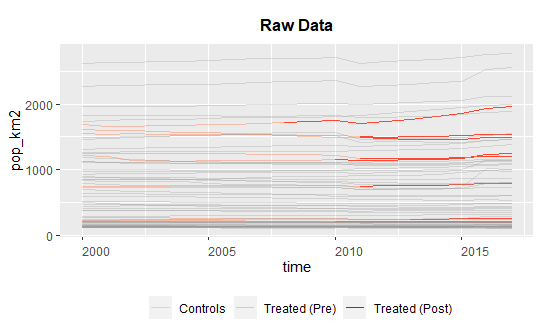

```r
panelView(pop_km2 ~ is_announced, data = n3_dta,
          index = c("geo","time"), type = "outcome")
```

```
Not a data frame.
```

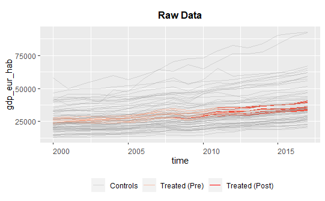

```r
panelView(gdp_eur_hab ~ is_announced, data = n3_dta,
          index = c("geo","time"), type = "outcome")
```

#### Factor analysis

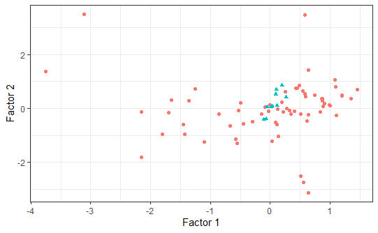

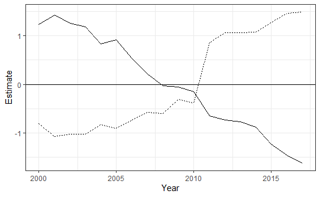

Regarding factors’ evolution:

“Bearing in mind the caveat that estimated factors may not be directly interpretable because they are, at best, linear transformations of the true factors, we find that the estimated factors shown in this figure are meaningful. The first factor captures the sharp increase in turnout in the southern states because of the 1965 Voting Rights Act that removed Jim Crow laws, such as poll taxes or literacy tests, that suppressed turnout.”

Regarding factor loadings:

“Another reassuring finding shown by Figure 3b is that the estimated factor loadings of the nine treated units mostly lie in the convex hull of those of the control units, which indicates that the treated counterfactuals are produced mostly by more reliable interpolations instead of extrapolations.” (paper Gsynth)

#### Individual effects and SE:

```
[1] "DEA5A"
[1] "DE143"
[1] "DEA1C"
[1] "DE724"
[1] "DEE03"
[1] "DE11C"
[1] "DED51"
[1] "DEA15"
[1] "DEA18"
[1] "DEG01"
```

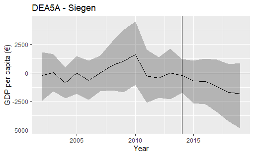

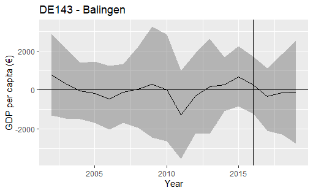

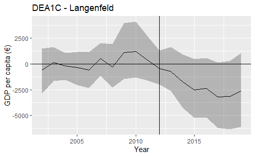

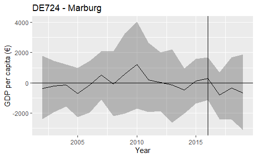

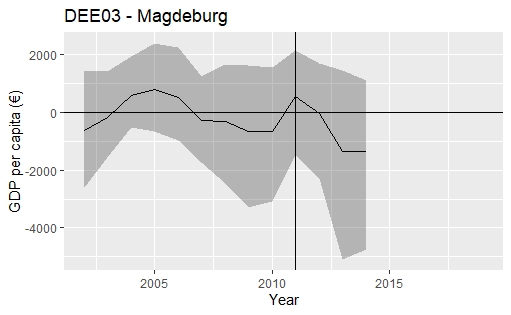

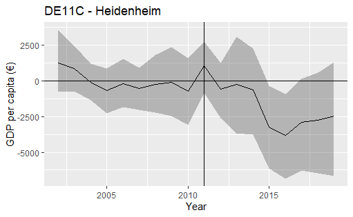

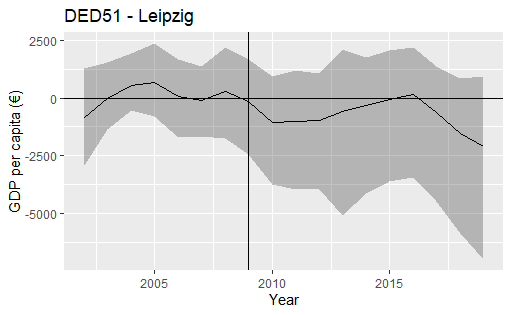

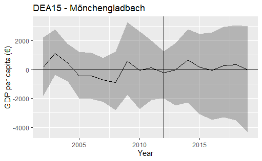

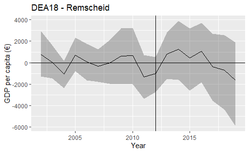

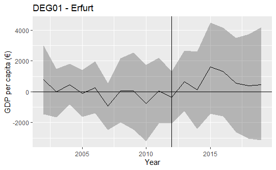

```r
for (i in n3_dta[n3_dta$treated_uz == TRUE, ]$geo %>% unique()){
  if (i %in% out_n2$id.tr){
    print(i)
    # pdf(file=paste0("images/prelim_results/ind_real_eff",
    #               "_",  i, ".pdf"),
    # width = 3.5, height = 3.1)
    plot_i <- out_n2$est.ind[, ,i] %>%
      as_tibble(rownames = "rel_time") %>%
      mutate(rel_time = 2010 + as.numeric(rel_time)) %>%
      ggplot(aes(x= rel_time, y = EFF, group = 1)) +
      geom_ribbon(aes(ymin = CI.lower, ymax = CI.upper),
                  alpha = 0.3) +
      geom_line() +
      geom_vline(xintercept = n3_dta[n3_dta$geo == i,]$year_announced[1]) +
      geom_hline(yintercept = 0) +
      labs(
        title = paste0(i, " - " ,n3_dta[n3_dta$geo == i,]$LEZ[1]),
        x = "Year",
        y = "GDP per capita (€)"
      )
    print(plot_i)
    # dev.off()
  }
}
```

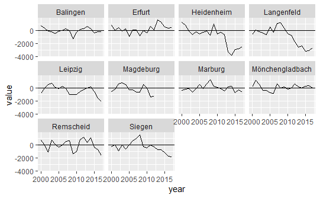

```r
temp <- out_n2$eff %>%
      as_tibble(rownames = "year") %>%
  pivot_longer(cols = is.numeric, names_to = "geo") %>%
  left_join(n3_dta %>% select(geo, year_announced, LEZ)) %>%
  mutate(year = as.numeric(year)) %>%
  unique()
ggplot(data = temp, aes(x= year, y = value)) +
  geom_line() +
  geom_hline(yintercept = 0) +
  # geom_vline(xintercept = n3_dta[n3_dta$geo == LEZ,]$year_announced[1]) +
  facet_wrap(vars(LEZ))
```

> Cities that have a negative impact are those where LEZ impact a significant proportion of the urban area of the zone and there is none very close LEZ already applied.

> Heiderberg has a sizable proportion of the popultion of the area. https://en.wikipedia.org/wiki/Heidenheim_(district)

#### Maps

```r
# Know the donor pool of each treated:
weights_result <- out_n2$wgt.implied %>%
  as_tibble(rownames = "NUTS_ID")

donor_pool <- nuts_treated %>%
  filter(LEVL_CODE == 3) %>%
  left_join(weights_result) %>%
  filter(!is.na(DEE03))
osm_units <- tmaptools::read_osm(donor_pool, ext=1.1)
# Get basemap for Germany

library("rnaturalearth")
library("rnaturalearthdata")

germany <- ne_countries(scale = "medium",
                      country = "germany",
                      returnclass = "sf")

donor_pool %>% as.data.frame() %>%
  select(NUTS_ID, DEE03) %>%
  arrange(desc(DEE03))
```

| NUTS_ID | DEE03 |
| --- | --- |
| DE243 | 3.824184219 |
| DE252 | 3.359859916 |
| DE222 | 1.527311760 |
| DE242 | 1.354771422 |
| DE273 | 1.245356648 |
| DE263 | 1.173948786 |
| DE251 | 1.124481685 |
| DE40B | 1.104297366 |
| DE241 | 0.903193540 |
| DE254 | 0.797215748 |

[output cut: 57 more lines]

```r
# Map of donor pools
leaflet() %>% addTiles() %>%
  addPolygons(data = donor_pool, weight = 0.5, color = "black",
              fillColor = ~colorQuantile("RdYlGn",
                      donor_pool$DEE03)(donor_pool$DEE03),
              popup = paste0(
                "<b>", donor_pool$NUTS_ID, "</b> <br/>",
                "<b> Weight Berlin </b>", donor_pool$DEE03, "<br/>",
                "<b> Weight Hannover </b>", donor_pool$DEE03, "<br/>")
              )
```

[interactive chart not shown]

```r
# Map of treated regions that were evaluated
nuts_treated %>%
  filter(NUTS_ID %in% out_n2$id.tr) %>%
  leaflet() %>% addTiles() %>%
  addPolygons()
```

[interactive chart not shown]

```
Raster values found that are outside the range [0, 255]
```

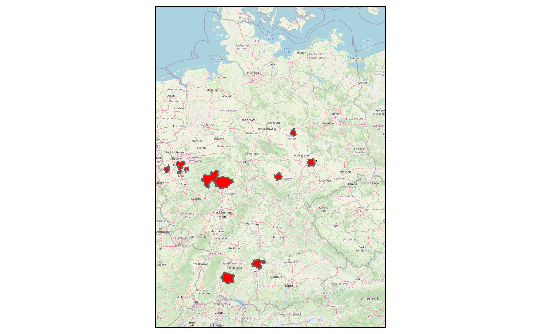

```r
tm_shape(osm_units) +
  tm_rgb() +
  tm_shape(nuts_treated %>%
             filter(NUTS_ID %in% out_n2$id.tr)) +
  tm_polygons( col = "red")
```

```r
# MAP of factors

factor_weights <- rbind(out_n2$lambda.co, out_n2$lambda.tr) %>%
  as_tibble(rownames = "NUTS_ID") %>%
  mutate(treatment = c(rep("Control", nrow(out_n2$lambda.co)),
                       rep("Treated", nrow(out_n2$lambda.tr)))) %>%
  mutate_if(is.numeric, function(x){(x-mean(x))/sd(x)})

factor_weights <- nuts_treated %>%
  right_join(factor_weights) %>%
  select(NUTS_ID, r1, r2, treatment) %>%
  rename(c("Factor 1" = r1, "Factor 2" = r2)) #, "Factor 3" = r3))
# # Factor 1, Rural - VS - Urban "economy" (or more gdp_capita)

tm_shape(osm_units) +
  tm_rgb() +
  tm_shape(factor_weights) +
  tm_polygons(col = "Factor 1") +
  tm_layout(legend.bg.color = "white")
```

[output not shown]

```
Raster values found that are outside the range [0, 255]
```

```r
# leaflet() %>% addTiles() %>%
#   addPolygons(data = factor_weights,
#               weight = 0.5,
#               color = "black",
#               fillColor = ~colorQuantile("RdYlGn",
#                       factor_weights$r1)(factor_weights$r1),
#               popup = paste0(
#                 "<b>", factor_weights$NUTS_ID, "</b> <br/>",
#                 "<b> Weight 1 </b>",
#                 factor_weights$r1, "<br/>",
#                 "<b> Weight 2 </b>",
#                 factor_weights$r2, "<br/>",
#                 "<b> Weight 3 </b>",
#                 factor_weights$r3, "<br/>")
#               )

# Investigate factor 1 and it's relation with GDP_capita
mean_gdp_cap <- apply(cbind(out_n2$Y.tr, out_n2$Y.co), 2, mean) %>%
  as_tibble(rownames = "NUTS_ID")

pdf(file="images/prelim_results/factor_1_gdp.pdf",
    width = 3, height = 3)
```

[figure not shown]

```r
factor_weights %>%
  left_join(mean_gdp_cap) %>% as.data.frame() %>%
  ggplot() +
  geom_point(aes(x = `Factor 1`, y = value)) +
  labs(x = "Factor 1", y = "Mean GDP per capita (€)") +
  theme_bw()
dev.off()
```

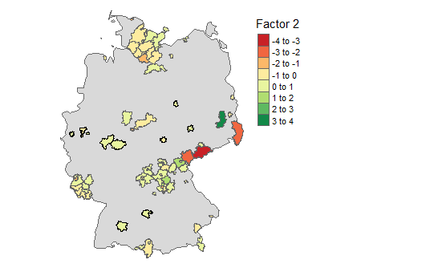

```r
# # Factor 2 ¿ Center germany VS hanburg + Duserldof + Stuttgart?

# pdf(file="images/prelim_results/factor_2_map.pdf",
#     width = 3, height = 3)
tm_shape(germany) +
  tm_polygons() +
tm_shape(factor_weights) +
  tm_polygons(col = "Factor 2") +
tm_shape(factor_weights %>% filter(treatment == "Treated")) +
  tm_borders(col = "black") +
  tm_layout(legend.bg.color = "white",
            legend.outside = TRUE, frame = FALSE)
```

```r
# dev.off()

# leaflet() %>% addTiles() %>%
#   addPolygons(data = factor_weights,
#               weight = 0.5,
#               color = "black",
#               fillColor = ~colorQuantile("RdYlGn",
#                       factor_weights$r2)(factor_weights$r2),
#               popup = paste0(
#                 "<b>", factor_weights$NUTS_ID, "</b> <br/>",
#                 "<b> Weight 1 </b>",
#                 factor_weights$r1, "<br/>",
#                 "<b> Weight 2 </b>",
#                 factor_weights$r2, "<br/>",
#                 "<b> Weight 3 </b>",
#                 factor_weights$r3, "<br/>")
              # )


## Factor 3 ??? NO IDEA

# pdf(file="images/prelim_results/factor_3_map.pdf",
#     width = 3, height = 4)
tm_shape(osm_units) +
  tm_rgb() +
  tm_shape(factor_weights) +
  tm_polygons(col = "Factor 3") +
  tm_layout(legend.bg.color = "white")
```

```
Raster values found that are outside the range [0, 255]Error: Fill argument neither colors nor valid variable name(s)
```